# Salvador_Escribano_ADO_PEC2

Pedro Salvador Escribano

4/6/2020

https://github.com/pesales/PEC2-An-lisis-de-datos-micos

# 1 Abstract

Se realizó un análisis de RNA-Seq a partir de los datos proporcionados. Se efectuó una extracción aleatoria de 10 muestras por grupo de un total de 3 grupos de muestras a analizar y se buscaron diferencias por pares. El análisis aportó las listas de genes diferencialmente expresados en cada una de las comparaciones

# 2 Objetivos

• Realizar una extracción aleatoria a partir de unos datos proporcionados.

• Llevar a cabo el análisis de expresión diferencial de los datos extraidos en el primer objetivo.

# 3 Materiales y Métodos

## 3.1 Naturaleza de los datos, tipo de experimento, diseño experimental

Los datos proporcionados para la realización de esta actividad corresponden a muestras de un estudio obtenido del repositorio (GTEx). Este repositorio contiene datos de múltiples tipos en un total de 54 tejidos. Nosotros nos centraremos en los datos de expresión (RNA-seq) pertenecientes a un análisis del tiroides en donde se compara tres tipos de infiltración medido en un total de 292 muestras pertenecientes a tres grupos:

• Not infiltrated tissues (NIT): 236 samples

• Small focal infiltrates (SFI): 42 samples

• Extensive lymphoid infiltrates (ELI): 14 samples.

## 3.2 Métodos y herramientas que habéis utilizado en el análisis:

El análisis de los datos será llevado a cabo en Rstudio, principalmente con las herramientas aportadas con el paquete DESeq2

### 3.2.1 Procedimiento general de análisis (pasos, “workflow” o “pipeline” que habéis seguido)

El proceso de análisis se ha estratificado de la siguiente manera: Definición de los datos. Preprocesado de los datos: filtraje y normalización. Identificación de genes diferencialmente expresados. Anotación de los resultados. Exportación de los resultados.

# 4 Resultados

Se ha obtenido las listas de genes cuya expresión se ve alterada en las diferentes condiciones analizadas y se ha almacenado dicha información en tablas en formato CSV. Para más detalle, consultar apéndice.

# 5 Discusión

En mi opinión, la mayor limitación que ofrece este tipo de estudios es el análisis estadístico de las diferencias en la expresión. Al ser un número de genes muy alto el que se analiza, los métodos estadísticos estandar fallan, reportando una gran cantidad de falsos positivos, por lo que se tiende a la realización de un ajuste del p-valor. La elección del nivel de significatividad adecuado condiciona notablemente los resultados obtenidos. Por otra parte, considero imprescindible una comunicación fluida entre el investigador y el analista bioinformático con el fin de no perder información que pueda ser relevante, pues es posible que, durante el procesado de los datos, información que aparentemente no es significativa para el analísta, sea de gran relevancia para el investigador por tener una relación más estrecha con el experimento.

# 6 Notas

Se ha omitido el (“Gene Enrichment Analysis”) al ser el número de genes que presentan diferencias en su expresión demasiado pequeño como para llevar a cabo este paso.

La anotación de los datos no se ha podido realizar completamente al haber algunos genes incluidos en el análisis que no tienen una entrada válida en la base de datos utilizadas. Para esos casos, se mantiene la nomenclatura inicial para poder ser consultada en caso de ser necesaria.

# 7 Apéndice

## 7.1 Definición de los datos

### 7.1.1 Importación de datos:

```r
counts=read.csv("C:/Users/peri8/Google Drive/Master UOC/Análisis de datos ómicos/PEC2/counts.csv", sep = ";")
targets=read.csv("C:/Users/peri8/Google Drive/Master UOC/Análisis de datos ómicos/PEC2/targets.csv")
```

### 7.1.2 Selección de muestra con n=10 para cada uno de los grupos:

```r
# Separo los 3 grupos:
NIT=subset(targets,Group=="NIT")
SFI=subset(targets,Group=="SFI")
ELI=subset(targets,Group=="ELI")
# Obtengo un muestreo aleatorio de 10 muestras por grupo en cada uno de los grupos:
set.seed(123)
require(dplyr)
sampleNIT=sample_n(NIT,size = 10)
sampleSFI=sample_n(SFI,size = 10)
sampleELI=sample_n(ELI,size = 10)
# Uno todos los muestreos en un solo data frame:
sampletargets=rbind(sampleNIT,sampleSFI,sampleELI)
# Extraigo las muestras seleccionadas del archivo counts:
rawCountTable=counts[,c(sampletargets$Sample_Name)]
rownames(rawCountTable)=counts$X
dim(rawCountTable)
```

```
## [1] 56202    30
```

```r
dim(sampletargets)
```

```
## [1] 30  9
```

### 7.1.3 Construcción del objeto DESeqDataSet:

```r
dds <- DESeqDataSetFromMatrix(countData = rawCountTable,colData = sampletargets, design = ~ Group)
dds
```

```
## class: DESeqDataSet
## dim: 56202 30
## metadata(1): version
## assays(1): counts
## rownames(56202): ENSG00000223972.4 ENSG00000227232.4 ...
##   ENSG00000210195.2 ENSG00000210196.2
## rowData names(0):
## colnames(30): GTEX.S341.0226.SM.5S2VG GTEX.ZAK1.0726.SM.5HL8Q ...
##   GTEX.13QBU.0626.SM.5J2OG GTEX.YFCO.0326.SM.4W1ZP
## colData names(9): Experiment SRA_Sample ... Group ShortName
```

## 7.2 Análisis exploratorio y visualización:

### 7.2.1 Prefiltrado de los datos:

```r
nrow(dds)
```

```
## [1] 56202
```

```r
dds <- dds[ rowSums(counts(dds)) > 1, ] # Elimino las filas con expresiones despreciables (menores o iguales a 1)
nrow(dds)
```

```
## [1] 43513
```

### 7.2.2 Normalización:

Realizo una normalización de los datos para poder llevar a cabo el análisis. Ya que se requiere homocedasticidad, considero el método vst el más adecuado para esta transformación.

```r
vsd <- vst(dds, blind = FALSE)
assay(vsd)[1:5, 1:5]
```

```
##                   GTEX.S341.0226.SM.5S2VG GTEX.ZAK1.0726.SM.5HL8Q
## ENSG00000223972.4                5.008719                4.589095
## ENSG00000227232.4                9.010059                9.376409
## ENSG00000243485.2                4.886335                4.898651
## ENSG00000237613.2                5.008719                5.026041
## ENSG00000268020.2                4.589095                4.898651
##                   GTEX.X15G.0526.SM.3NMB7 GTEX.11DYG.0826.SM.5N9GH
## ENSG00000223972.4                6.066370                 5.098513
## ENSG00000227232.4                9.821541                 9.589787
## ENSG00000243485.2                5.322253                 4.589095
## ENSG00000237613.2                5.379618                 4.589095
## ENSG00000268020.2                5.189829                 4.589095
##                   GTEX.Y5V6.0526.SM.4VBRV
## ENSG00000223972.4                5.054871
## ENSG00000227232.4                8.824796
## ENSG00000243485.2                5.054871
## ENSG00000237613.2                4.969947
## ENSG00000268020.2                4.969947
```

```r
colData(vsd)
```

```
## DataFrame with 30 rows and 10 columns
##                          Experiment SRA_Sample              Sample_Name
##                            <factor>   <factor>                 <factor>
## GTEX.S341.0226.SM.5S2VG   SRX221539  SRS389105  GTEX-S7SE-0726-SM-2XCD7
## GTEX.ZAK1.0726.SM.5HL8Q   SRX577234  SRS629488  GTEX-ZC5H-0626-SM-5LU9K
## GTEX.X15G.0526.SM.3NMB7   SRX407742  SRS524447  GTEX-X4XY-0826-SM-4E3JM
## GTEX.11DYG.0826.SM.5N9GH  SRX579805  SRS629854 GTEX-11DZ1-2726-SM-5A5KH
## GTEX.Y5V6.0526.SM.4VBRV   SRX590541  SRS634561  GTEX-Y8E4-0126-SM-4VBQ2
## ...                             ...        ...                      ...
## GTEX.111FC.1026.SM.5GZX1  SRX563960  SRS625636 GTEX-111VG-0526-SM-5N9BW
## GTEX.TKQ1.0126.SM.33HB3   SRX222429  SRS389623  GTEX-TMMY-0826-SM-33HB9
## GTEX.ZYW4.1126.SM.5SI99   SRX568364  SRS627095  GTEX-ZYY3-1926-SM-5GZXS
## GTEX.13QBU.0626.SM.5J2OG  SRX601511  SRS638114 GTEX-13QJC-0826-SM-5RQKC
## GTEX.YFCO.0326.SM.4W1ZP   SRX583148  SRS631283  GTEX-YJ89-0726-SM-5P9F7
##                          Grupo_analisis body_site        molecular_data_type
##                               <integer>  <factor>                   <factor>
## GTEX.S341.0226.SM.5S2VG               1   Thyroid              RNA Seq (NGS)
## GTEX.ZAK1.0726.SM.5HL8Q               1   Thyroid              RNA Seq (NGS)
## GTEX.X15G.0526.SM.3NMB7               1   Thyroid Allele-Specific Expression
## GTEX.11DYG.0826.SM.5N9GH              1   Thyroid Allele-Specific Expression
## GTEX.Y5V6.0526.SM.4VBRV               1   Thyroid              RNA Seq (NGS)
## ...                                 ...       ...                        ...
## GTEX.111FC.1026.SM.5GZX1              3   Thyroid              RNA Seq (NGS)
## GTEX.TKQ1.0126.SM.33HB3               3   Thyroid Allele-Specific Expression
## GTEX.ZYW4.1126.SM.5SI99               3   Thyroid Allele-Specific Expression
## GTEX.13QBU.0626.SM.5J2OG              3   Thyroid Allele-Specific Expression
## GTEX.YFCO.0326.SM.4W1ZP               3   Thyroid              RNA Seq (NGS)
##                               sex    Group ShortName        sizeFactor
##                          <factor> <factor>  <factor>         <numeric>
## GTEX.S341.0226.SM.5S2VG      male      NIT S7SE-_NIT 0.975311461378106
## GTEX.ZAK1.0726.SM.5HL8Q    female      NIT ZC5H-_NIT 0.898982680186865
## GTEX.X15G.0526.SM.3NMB7      male      NIT X4XY-_NIT 0.944764423567596
## GTEX.11DYG.0826.SM.5N9GH     male      NIT 11DZ1_NIT  1.31916123634567
## GTEX.Y5V6.0526.SM.4VBRV      male      NIT Y8E4-_NIT  1.18547273258289
## ...                           ...      ...       ...               ...
## GTEX.111FC.1026.SM.5GZX1     male      ELI 111VG_ELI  1.08969111335825
## GTEX.TKQ1.0126.SM.33HB3    female      ELI TMMY-_ELI  1.68631884234377
## GTEX.ZYW4.1126.SM.5SI99    female      ELI ZYY3-_ELI 0.938490380963618
## GTEX.13QBU.0626.SM.5J2OG   female      ELI 13QJC_ELI 0.933150561711403
## GTEX.YFCO.0326.SM.4W1ZP      male      ELI YJ89-_ELI  1.37509415513796
```

### 7.2.3 Evaluación de clustering entre muestras:

#### 7.2.3.1 Cálculo de distancia entre muestras y representación mediante heatmap:

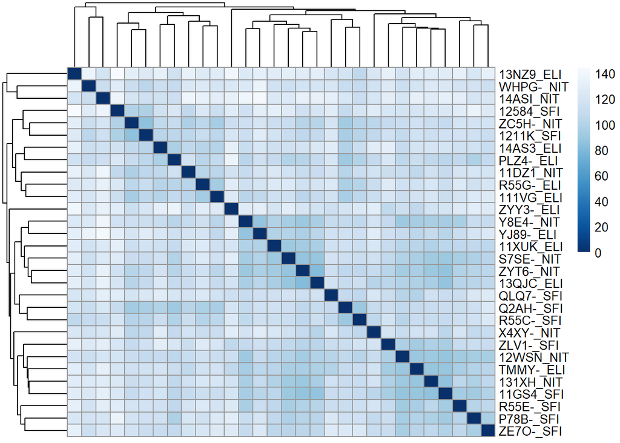

```r
sampleDists <- dist(t(assay(vsd)))
library("pheatmap")
library("RColorBrewer")
sampleDistMatrix <- as.matrix( sampleDists )
rownames(sampleDistMatrix) <- paste(vsd$ShortName)
colnames(sampleDistMatrix) <- NULL
colors <- colorRampPalette( rev(brewer.pal(9, "Blues")) )(255)
pheatmap(sampleDistMatrix,
         clustering_distance_rows = sampleDists,
         clustering_distance_cols = sampleDists,
         col = colors)
```

#### 7.2.3.2 Análisis de componentes principales:

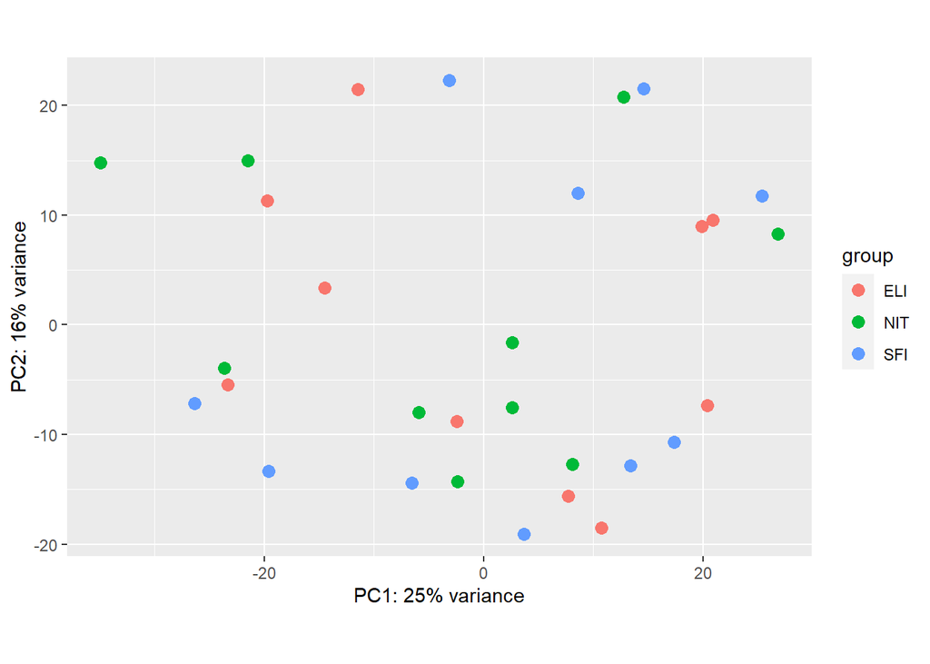

```r
plotPCA(vsd, intgroup = c("Group"))
```

#### 7.2.3.3 MDS plot:

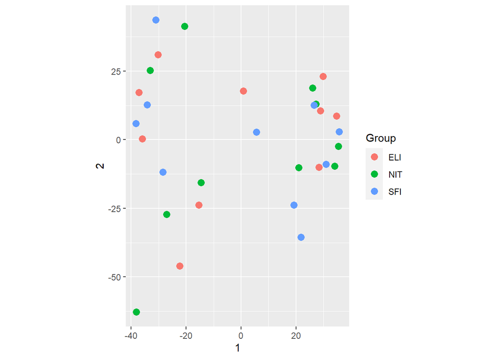

```r
mds <- as.data.frame(colData(vsd))  %>%
         cbind(cmdscale(sampleDistMatrix))
ggplot(mds, aes(x = `1`, y = `2`, color = Group)) +
  geom_point(size = 3) + coord_fixed()
```

A priori, no se aprecia claramente ningún tipo de agrupamiento entre las muestras.

## 7.3 Identificación de genes diferencialmente expresados

Se realizarán 3 comparaciones: SFI-NIT, ELI-NIT y ELI-SFI.

```r
dds <- DESeq(dds, parallel =TRUE)
```

```
## -- replacing outliers and refitting for 497 genes
## -- DESeq argument 'minReplicatesForReplace' = 7
## -- original counts are preserved in counts(dds)
```

### 7.3.1 SFI-NIT

En primer lugar realizo el análisis y muestro los resultados del mismo

```r
SFINITres <- results(dds, contrast=c("Group","SFI","NIT"))
SFINITres
```

```
## log2 fold change (MLE): Group SFI vs NIT
## Wald test p-value: Group SFI vs NIT
## DataFrame with 43513 rows and 6 columns
##                           baseMean      log2FoldChange             lfcSE
##                          <numeric>           <numeric>         <numeric>
## ENSG00000223972.4 4.53917358219955   0.321640332243348 0.690368689639189
## ENSG00000227232.4 670.892244359886   0.117096934716329 0.187928076614192
## ENSG00000243485.2 2.13920928094679    0.88755620472059 0.742624514175677
## ENSG00000237613.2 1.88160561198927  -0.116680281105258 0.688835256002655
## ENSG00000268020.2 1.05567101623418   0.976304510869576 0.944837192358173
## ...                            ...                 ...               ...
## ENSG00000198695.2 76717.2806683366   -0.31085775938108 0.591644295502924
## ENSG00000210194.1 41.4845000098372 -0.0714766875607364 0.818548217763293
## ENSG00000198727.2 511745.795563112   0.230653383717484 0.281916766540973
## ENSG00000210195.2 1.11108276000739   0.385610031964092  1.16676164055833
## ENSG00000210196.2 3.53507751987634   -1.02930559926067 0.728002935952893
##                                  stat            pvalue      padj
##                             <numeric>         <numeric> <numeric>
## ENSG00000223972.4   0.465896465280672 0.641289611391659         1
## ENSG00000227232.4   0.623094413703406 0.533222480498503         1
## ENSG00000243485.2    1.19516146824993 0.232023949836332         1
## ENSG00000237613.2  -0.169387789153475 0.865491627566832         1
## ENSG00000268020.2    1.03330448755183 0.301461427857032         1
## ...                               ...               ...       ...
## ENSG00000198695.2  -0.525413262231891 0.599295936037352         1
## ENSG00000210194.1 -0.0873212915374107 0.930416130461572         1
## ENSG00000198727.2    0.81816128408227 0.413265098968156         1
## ENSG00000210195.2   0.330495980121156 0.741025229551141         1
## ENSG00000210196.2    -1.4138756156435 0.157398426680564         1
```

```r
summary(SFINITres)
```

```
##
## out of 43507 with nonzero total read count
## adjusted p-value < 0.1
## LFC > 0 (up)       : 0, 0%
## LFC < 0 (down)     : 1, 0.0023%
## outliers [1]       : 0, 0%
## low counts [2]     : 6, 0.014%
## (mean count < 0)
## [1] see 'cooksCutoff' argument of ?results
## [2] see 'independentFiltering' argument of ?results
```

Considerando un p-valor ajustado de 0.1, muestro cuántos genes son significativamente diferentes en esta comparación:

```r
table(SFINITres$padj < 0.1)
```

```
##
## FALSE  TRUE
## 43506     1
```

```r
SFINITresSig <- subset(SFINITres, padj < 0.1)
SFINITdownreg <- subset(SFINITresSig,log2FoldChange<0)
head(SFINITdownreg[ order(SFINITdownreg$log2FoldChange), ])
```

```
## log2 fold change (MLE): Group SFI vs NIT
## Wald test p-value: Group SFI vs NIT
## DataFrame with 1 row and 6 columns
##                           baseMean    log2FoldChange             lfcSE
##                          <numeric>         <numeric>         <numeric>
## ENSG00000225972.1 2385.93178694658 -5.58136590652377 0.822759009483037
##                                stat               pvalue                 padj
##                           <numeric>            <numeric>            <numeric>
## ENSG00000225972.1 -6.78371897748127 1.17121048829752e-11 5.09558547143602e-07
```

```r
SFINITupreg <- subset(SFINITresSig,log2FoldChange>0)
head(SFINITupreg[ order(SFINITupreg$log2FoldChange, decreasing = TRUE), ])
```

```
## log2 fold change (MLE): Group SFI vs NIT
## Wald test p-value: Group SFI vs NIT
## DataFrame with 0 rows and 6 columns
```

### 7.3.2 ELI-NIT

En primer lugar realizo el análisis y muestro los resultados del mismo

```r
ELINITres <- results(dds, contrast=c("Group","ELI","NIT"))
ELINITres
```

```
## log2 fold change (MLE): Group ELI vs NIT
## Wald test p-value: Group ELI vs NIT
## DataFrame with 43513 rows and 6 columns
##                           baseMean      log2FoldChange             lfcSE
##                          <numeric>           <numeric>         <numeric>
## ENSG00000223972.4 4.53917358219955  -0.512916872909814  0.70773340672622
## ENSG00000227232.4 670.892244359886   0.302588865193538 0.187781284561297
## ENSG00000243485.2 2.13920928094679   0.269809776460455 0.762961953075233
## ENSG00000237613.2 1.88160561198927  -0.678619904675883 0.715390502654744
## ENSG00000268020.2 1.05567101623418  -0.277234863810067  1.02177444753393
## ...                            ...                 ...               ...
## ENSG00000198695.2 76717.2806683366  -0.193140646300286  0.59164374890405
## ENSG00000210194.1 41.4845000098372   0.641515018367216 0.816917938053864
## ENSG00000198727.2 511745.795563112 -0.0717923282623401 0.281916849924084
## ENSG00000210195.2 1.11108276000739  -0.811121818990446  1.23076515995891
## ENSG00000210196.2 3.53507751987634 -0.0918735124725379 0.692598175308102
##                                 stat            pvalue      padj
##                            <numeric>         <numeric> <numeric>
## ENSG00000223972.4  -0.72473175356018 0.468616610871673         1
## ENSG00000227232.4   1.61138989916093 0.107094767402009         1
## ENSG00000243485.2  0.353634641115387 0.723612709931909         1
## ENSG00000237613.2 -0.948600662376131 0.342823753997418         1
## ENSG00000268020.2 -0.271326871090952 0.786139641204098         1
## ...                              ...               ...       ...
## ENSG00000198695.2 -0.326447539854949 0.744085774160543         1
## ENSG00000210194.1  0.785286977411086 0.432285329357048         1
## ENSG00000198727.2 -0.254657812336058 0.798987402996748         1
## ENSG00000210195.2 -0.659038657722103  0.50987094488251         1
## ENSG00000210196.2 -0.132650526305051 0.894469771259743         1
```

```r
summary(ELINITres)
```

```
##
## out of 43507 with nonzero total read count
## adjusted p-value < 0.1
## LFC > 0 (up)       : 0, 0%
## LFC < 0 (down)     : 4, 0.0092%
## outliers [1]       : 0, 0%
## low counts [2]     : 6, 0.014%
## (mean count < 0)
## [1] see 'cooksCutoff' argument of ?results
## [2] see 'independentFiltering' argument of ?results
```

Considerando un alpha de 0.05 y un p-valor ajustado de 0.1, muestro cuántos genes son significativamente diferentes en esta comparación:

```r
table(ELINITres$padj < 0.1)
```

```
##
## FALSE  TRUE
## 43503     4
```

A continuación, exraigo estos resultados y muestro los genes ordenados por mayor cambio en la expresión a la baja, es decir, que se expresan menos en ELI que en NIT:

```r
ELINITresSig <- subset(ELINITres, padj < 0.1)
ELINITdownreg <- subset(ELINITresSig,log2FoldChange<0)
head(ELINITdownreg[ order(ELINITdownreg$log2FoldChange), ])
```

```
## log2 fold change (MLE): Group ELI vs NIT
## Wald test p-value: Group ELI vs NIT
## DataFrame with 4 rows and 6 columns
##                            baseMean    log2FoldChange             lfcSE
##                           <numeric>         <numeric>         <numeric>
## ENSG00000225972.1  2385.93178694658 -5.91793364217918 0.822928077671824
## ENSG00000099194.5  1465.01215402933 -3.48415209388505 0.782870861729024
## ENSG00000016082.10 37.1448499331103 -2.90692051323182 0.640282345601159
## ENSG00000125675.13 70.1140803007431 -2.62431047377788  0.58989127093801
##                                 stat               pvalue                 padj
##                            <numeric>            <numeric>            <numeric>
## ENSG00000225972.1  -7.19131331491547 6.41710326487621e-13 2.79188911744969e-08
## ENSG00000099194.5  -4.45048125330666 8.56780729380978e-06   0.0939206112036599
## ENSG00000016082.10 -4.54006038617623   5.623811933063e-06   0.0939206112036599
## ENSG00000125675.13 -4.44880370852897 8.63498850333601e-06   0.0939206112036599
```

Y por mayor a menor cambio en la expresión al alza, es decir, que se expresan mas en ELI que en NIT:

```r
ELINITupreg <- subset(ELINITresSig,log2FoldChange>0)
head(ELINITupreg[ order(ELINITupreg$log2FoldChange, decreasing = TRUE), ])
```

```
## log2 fold change (MLE): Group ELI vs NIT
## Wald test p-value: Group ELI vs NIT
## DataFrame with 0 rows and 6 columns
```

### 7.3.3 ELI-SFI

En primer lugar realizo el análisis y muestro los resultados del mismo

```r
ELISFIres <- results(dds, contrast=c("Group","ELI","SFI"))
ELISFIres
```

```
## log2 fold change (MLE): Group ELI vs SFI
## Wald test p-value: Group ELI vs SFI
## DataFrame with 43513 rows and 6 columns
##                           baseMean     log2FoldChange             lfcSE
##                          <numeric>          <numeric>         <numeric>
## ENSG00000223972.4 4.53917358219955 -0.834557205153162 0.699778252249183
## ENSG00000227232.4 670.892244359886  0.185491930477209 0.187667342628895
## ENSG00000243485.2 2.13920928094679 -0.617746428260135 0.717825952410277
## ENSG00000237613.2 1.88160561198927 -0.561939623570626 0.717664397297725
## ENSG00000268020.2 1.05567101623418  -1.25353937467964 0.953694238440694
## ...                            ...                ...               ...
## ENSG00000198695.2 76717.2806683366  0.117717113080794 0.591644157385173
## ENSG00000210194.1 41.4845000098372  0.712991705927952 0.816940085428019
## ENSG00000198727.2 511745.795563112 -0.302445711979825 0.281916702982957
## ENSG00000210195.2 1.11108276000739  -1.19673185095454  1.20987533564232
## ENSG00000210196.2 3.53507751987634  0.937432086788132 0.726389050863307
##                                 stat            pvalue              padj
##                            <numeric>         <numeric>         <numeric>
## ENSG00000223972.4  -1.19260237435328 0.233025135530346 0.774785570094762
## ENSG00000227232.4   0.98840814751671 0.322952798879753 0.833646666275435
## ENSG00000243485.2 -0.860579679775995 0.389469581510169 0.861997589699303
## ENSG00000237613.2  -0.78301170531315 0.433620238348385 0.882181258118991
## ENSG00000268020.2  -1.31440384575375 0.188710336978403                NA
## ...                              ...               ...               ...
## ENSG00000198695.2  0.198966070418164 0.842289285807328 0.979967784845527
## ENSG00000210194.1  0.872758870137208 0.382794522262548  0.85895087348915
## ENSG00000198727.2  -1.07281941360569 0.283352148632567 0.810402876391662
## ENSG00000210195.2 -0.989136496711207 0.322596363168558                NA
## ENSG00000210196.2   1.29053719308407 0.196864206866378 0.745421563280012
```

```r
summary(ELISFIres)
```

```
##
## out of 43507 with nonzero total read count
## adjusted p-value < 0.1
## LFC > 0 (up)       : 35, 0.08%
## LFC < 0 (down)     : 34, 0.078%
## outliers [1]       : 0, 0%
## low counts [2]     : 14346, 33%
## (mean count < 1)
## [1] see 'cooksCutoff' argument of ?results
## [2] see 'independentFiltering' argument of ?results
```

Considerando un alpha de 0.05 y un p-valor ajustado de 0.1, muestro cuántos genes son significativamente diferentes en esta comparación:

```r
table(ELISFIres$padj < 0.1)
```

```
##
## FALSE  TRUE
## 29098    69
```

A continuación, exraigo estos resultados y muestro los genes ordenados por mayor cambio en la expresión a la baja, es decir, que se expresan menos en ELI que en SFI (muestro solo los 5 primieros):

```r
ELISFIresSig <- subset(ELISFIres, padj < 0.1)
ELISFIdownreg <- subset(ELISFIresSig,log2FoldChange<0)
head(ELISFIdownreg[ order(ELISFIdownreg$log2FoldChange), ], 5)
```

```
## log2 fold change (MLE): Group ELI vs SFI
## Wald test p-value: Group ELI vs SFI
## DataFrame with 5 rows and 6 columns
##                            baseMean    log2FoldChange             lfcSE
##                           <numeric>         <numeric>         <numeric>
## ENSG00000110680.8  9969.14140220374 -6.11389361676835  1.57083356705019
## ENSG00000259846.1  5.66201687165021 -5.43441311173801  1.46699905580045
## ENSG00000256021.1   2.2469584142427 -3.39939571808126 0.827087315484252
## ENSG00000223553.1  3.97793030212305 -2.93292319907057 0.749703481429823
## ENSG00000016082.10 37.1448499331103 -2.88329855517083 0.640193741193381
##                                 stat               pvalue               padj
##                            <numeric>            <numeric>          <numeric>
## ENSG00000110680.8  -3.89213328834665 9.93666256985189e-05 0.0807149802224517
## ENSG00000259846.1  -3.70444213324514 0.000211856462264458 0.0950648836133453
## ENSG00000256021.1  -4.11008082754956 3.95520647766885e-05 0.0807149802224517
## ENSG00000223553.1  -3.91211095015451 9.14928578157068e-05 0.0807149802224517
## ENSG00000016082.10 -4.50379060219504 6.67519816894377e-06 0.0585708038035861
```

Y por mayor a menor cambio en la expresión al alza, es decir, que se expresan mas en ELI que en SFI, (muestro solo los 5 primieros):

```r
ELISFIupreg <- subset(ELISFIresSig,log2FoldChange>0)
head(ELISFIupreg[ order(ELISFIupreg$log2FoldChange, decreasing = TRUE), ],5)
```

```
## log2 fold change (MLE): Group ELI vs SFI
## Wald test p-value: Group ELI vs SFI
## DataFrame with 5 rows and 6 columns
##                            baseMean   log2FoldChange             lfcSE
##                           <numeric>        <numeric>         <numeric>
## ENSG00000092758.11 6110.67006019468 2.79825944117508 0.695919165158303
## ENSG00000225383.2  51.7243663525045  2.5143660889107 0.675445544035939
## ENSG00000135069.9  1012.22959924315  2.1204237690974 0.529426250652791
## ENSG00000150051.9  72.9236542320438 1.67445367689069 0.429322484459516
## ENSG00000226944.1  29.8204088557369 1.09619283752744 0.297968533231977
##                                stat               pvalue               padj
##                           <numeric>            <numeric>          <numeric>
## ENSG00000092758.11 4.02095470461508 5.79627505510231e-05 0.0807149802224517
## ENSG00000225383.2  3.72252968594152 0.000197236710561924 0.0950648836133453
## ENSG00000135069.9  4.00513530729329 6.19819919309922e-05 0.0807149802224517
## ENSG00000150051.9  3.90022357901589 9.61038963632936e-05 0.0807149802224517
## ENSG00000226944.1  3.67888792026915 0.000234253178634445 0.0999457549054777
```

## 7.4 Anotación de los resultados:

Dado que el nombre ENSEMBL de los genes es poco informativo, es conveniente anotar los resultados para una mejor interpretación.

### 7.4.1 SFI-NIT

```r
# En primer lugar ajusto la nomenclatura a la adecuada para llevar a cabo la anotación
rownames(SFINITres) <- gsub("\\..*", "", rownames(SFINITres), fixed = FALSE)
# Tras esto ya puedo realizar la anotación correctamente
library("AnnotationDbi")
SFINITres$symbol <- mapIds(org.Hs.eg.db,
                           keys = rownames(SFINITres),
                           column = "SYMBOL",
                           keytype = "ENSEMBL",
                           multiVals="first")
SFINITres$entrez  <- mapIds(org.Hs.eg.db,
                           keys = rownames(SFINITres),
                           column = "ENTREZID",
                           keytype = "ENSEMBL",
                           multiVals="first")
SFINITresOrdered <- SFINITres[order(SFINITres$pvalue),]
head(SFINITresOrdered)
```

```
## log2 fold change (MLE): Group SFI vs NIT
## Wald test p-value: Group SFI vs NIT
## DataFrame with 6 rows and 8 columns
##                         baseMean     log2FoldChange             lfcSE
##                        <numeric>          <numeric>         <numeric>
## ENSG00000225972 2385.93178694658  -5.58136590652377 0.822759009483037
## ENSG00000099866 101.739204947545  -1.45779463220455 0.356960783721761
## ENSG00000143546 519.384545188698   1.27948272624513 0.328656390015101
## ENSG00000205592  3.4283761196695   3.88641375706823  1.11382580328716
## ENSG00000231205 248.152120026799 -0.799538930671605 0.231295559203946
## ENSG00000233942 8.21808507693208   -1.8703762146968 0.542326447664897
##                              stat               pvalue                 padj
##                         <numeric>            <numeric>            <numeric>
## ENSG00000225972 -6.78371897748127 1.17121048829752e-11 5.09558547143602e-07
## ENSG00000099866 -4.08390696872978 4.42847659586296e-05    0.963348656281048
## ENSG00000143546  3.89307119872623 9.89830861532751e-05                    1
## ENSG00000205592  3.48924737207425 0.000484382668293054                    1
## ENSG00000231205  -3.4567846154219 0.000546661588564391                    1
## ENSG00000233942 -3.44880140503955 0.000563080663701698                    1
##                      symbol      entrez
##                 <character> <character>
## ENSG00000225972          NA          NA
## ENSG00000099866     MADCAM1        8174
## ENSG00000143546      S100A8        6279
## ENSG00000205592       MUC19      283463
## ENSG00000231205          NA          NA
## ENSG00000233942          NA          NA
```

### 7.4.2 ELI-NIT

```r
# En primer lugar ajusto la nomenclatura a la adecuada para llevar a cabo la anotación
rownames(ELINITres) <- gsub("\\..*", "", rownames(ELINITres), fixed = FALSE)
# Tras esto ya puedo realizar la anotación correctamente
library("AnnotationDbi")
ELINITres$symbol <- mapIds(org.Hs.eg.db,
                           keys = rownames(ELINITres),
                           column = "SYMBOL",
                           keytype = "ENSEMBL",
                           multiVals="first")
ELINITres$entrez  <- mapIds(org.Hs.eg.db,
                           keys = rownames(ELINITres),
                           column = "ENTREZID",
                           keytype = "ENSEMBL",
                           multiVals="first")
ELINITresOrdered <- ELINITres[order(ELINITres$pvalue),]
head(ELINITresOrdered)
```

```
## log2 fold change (MLE): Group ELI vs NIT
## Wald test p-value: Group ELI vs NIT
## DataFrame with 6 rows and 8 columns
##                         baseMean    log2FoldChange             lfcSE
##                        <numeric>         <numeric>         <numeric>
## ENSG00000225972 2385.93178694658 -5.91793364217918 0.822928077671824
## ENSG00000016082 37.1448499331103 -2.90692051323182 0.640282345601159
## ENSG00000099194 1465.01215402933 -3.48415209388505 0.782870861729024
## ENSG00000125675 70.1140803007431 -2.62431047377788  0.58989127093801
## ENSG00000162105 2725.69481826633 0.585152084983046 0.139376023225019
## ENSG00000089199 408.423759865464 -3.72095095262579   0.8957264841416
##                              stat               pvalue                 padj
##                         <numeric>            <numeric>            <numeric>
## ENSG00000225972 -7.19131331491547 6.41710326487621e-13 2.79188911744969e-08
## ENSG00000016082 -4.54006038617623   5.623811933063e-06   0.0939206112036599
## ENSG00000099194 -4.45048125330666 8.56780729380978e-06   0.0939206112036599
## ENSG00000125675 -4.44880370852897 8.63498850333601e-06   0.0939206112036599
## ENSG00000162105  4.19836978730792 2.68843368408977e-05    0.233931368587388
## ENSG00000089199 -4.15411514396795 3.26548718661252e-05    0.236139498811211
##                      symbol      entrez
##                 <character> <character>
## ENSG00000225972          NA          NA
## ENSG00000016082        ISL1        3670
## ENSG00000099194         SCD        6319
## ENSG00000125675       GRIA3        2892
## ENSG00000162105      SHANK2       22941
## ENSG00000089199        CHGB        1114
```

### 7.4.3 ELI-SFI

```r
# En primer lugar ajusto la nomenclatura a la adecuada para llevar a cabo la anotación
rownames(ELISFIres) <- gsub("\\..*", "", rownames(ELISFIres), fixed = FALSE)
# Tras esto ya puedo realizar la anotación correctamente
library("AnnotationDbi")
ELISFIres$symbol <- mapIds(org.Hs.eg.db,
                           keys = rownames(ELISFIres),
                           column = "SYMBOL",
                           keytype = "ENSEMBL",
                           multiVals="first")
ELISFIres$entrez  <- mapIds(org.Hs.eg.db,
                           keys = rownames(ELISFIres),
                           column = "ENTREZID",
                           keytype = "ENSEMBL",
                           multiVals="first")
ELISFIresOrdered <- ELISFIres[order(ELISFIres$pvalue),]
head(ELISFIresOrdered)
```

```
## log2 fold change (MLE): Group ELI vs SFI
## Wald test p-value: Group ELI vs SFI
## DataFrame with 6 rows and 8 columns
##                         baseMean    log2FoldChange              lfcSE
##                        <numeric>         <numeric>          <numeric>
## ENSG00000065882 7519.86791630768 0.355919705836386 0.0715804667311189
## ENSG00000139168 1592.24479322926 0.552703167797859  0.120617389305866
## ENSG00000016082 37.1448499331103 -2.88329855517083  0.640193741193381
## ENSG00000231205 248.152120026799  1.03074857243472  0.230886088164035
## ENSG00000254165 77.2711553569672 -1.00925708830735   0.23224524864338
## ENSG00000232027 6.80131678992827 -1.69078693318295  0.394873323222044
##                              stat               pvalue               padj
##                         <numeric>            <numeric>          <numeric>
## ENSG00000065882  4.97230211104022 6.61624932620464e-07 0.0192976144097411
## ENSG00000139168  4.58228428735341 4.59924047806455e-06 0.0585708038035861
## ENSG00000016082 -4.50379060219504 6.67519816894377e-06 0.0585708038035861
## ENSG00000231205   4.4643164975034 8.03247557905662e-06 0.0585708038035861
## ENSG00000254165 -4.34565225425599 1.38862412545849e-05 0.0807149802224517
## ENSG00000232027 -4.28184643973073 1.85348877105353e-05 0.0807149802224517
##                      symbol      entrez
##                 <character> <character>
## ENSG00000065882      TBC1D1       23216
## ENSG00000139168       ZCRB1       85437
## ENSG00000016082        ISL1        3670
## ENSG00000231205          NA          NA
## ENSG00000254165          NA          NA
## ENSG00000232027          NA          NA
```

## 7.5 Exportación de los datos:

```r
SFINITresOrderedDF <- as.data.frame(SFINITresOrdered)
write.csv(SFINITresOrderedDF, file = "resultsSFI_NIT.csv")
ELINITresOrderedDF <- as.data.frame(ELINITresOrdered)
write.csv(ELINITresOrderedDF, file = "resultsELI_NIT.csv")
ELISFIresOrderedDF <- as.data.frame(ELISFIresOrdered)
write.csv(ELISFIresOrderedDF, file = "resultsELI_SFI.csv")
```